# From HyPlant to FLEX upscaling procedure

D. Emin

## Summary

> - HyPlant images can be used to simulate SIF at 300 m resolution
> - The procedure to scale-up SIF and land cover (LC) to 300 m involves a polygon grid cell
> - For each grid cell SIF 760, proportion of LC, and SIF contribution from each land cover is calculated

## FLEX and HyPlant

FLEX satellite is the upcomming scientific satellite mission from ESA. It will monitor global SIF levels at 300 m spatial resolution. HyPlant is an airborn hyperspectral device used for SIF retrieval at nominal spatial resolution of 1 m. HyPlant can be used to simulate SIF at 300 meter and study the scaling effects.

Here, the procedure to derive SIF values at 300 meter spatial resolution is described. We will create a vector grid. Then the grid will be overlayed with the SIF map from HyPlant and the land cover map. For each grid cell we will extract proportion of land cover, average SIF, and average SIF per land cover.

## Input data

Input data includes:

- SIF map from 2017 over Selhausen study area at 1m spatial resolution
- Vector land cover map of the same area contains the following classes:

```r
unique(land.cover$LUSE_21_Se)
```

```
##  [1] Small_Crop     Mustard_Radish Bare_Soil      Sugar_Beet
##  [5] Corn           Grass          Cabbage        ND
##  [9] Tree           Settlement     Potato         Lattuce
## [13] Carrot         Road
## 14 Levels: Bare_Soil Cabbage Carrot Corn Grass Lattuce ... Tree
```

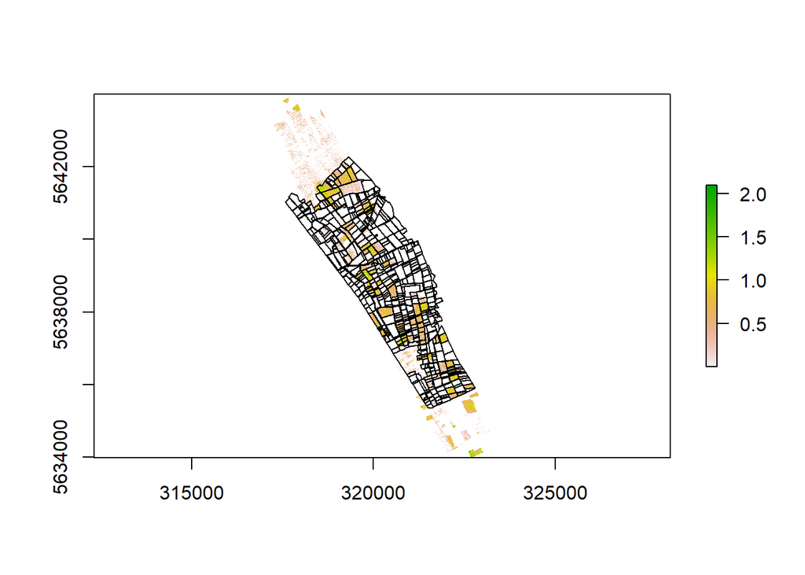

```r
plot(sel.sif.2017)
plot(land.cover, add=T)
```

## Creating 300 meter resolution grid

First, we create a 300 by 300 grid to which all relevant information will be recorderd as attribute table. Another reason to use this approach is the significant savings on disc space and computation time.

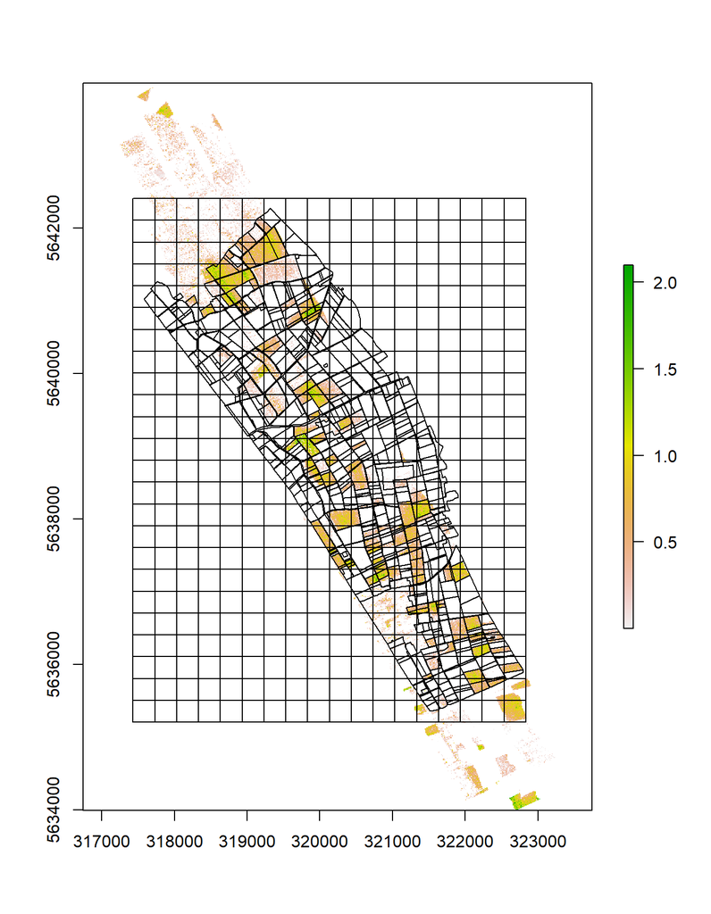

```r
# directly taken from PennState College of Agricultural Sciences Manula on Spatial Ecology
# https://ecosystems.psu.edu/research/labs/walter-lab/manual/chapter1/1.9-creating-a-square-polygon-grid-over-a-study-area

# Since the Land cover layer is slightly smaller, we will use it to define the extend for our grid
ex <- extent(land.cover)

#Set sequence of coordinates along the extend at 300 m spacing
xcor <- seq(ex[1], ex[2], by= 300)
ycor <- seq(ex[3], ex[4], by= 300)

# expand (make a data frame with all possible combinations)
xy <- expand.grid(x=xcor, y=ycor)

#take CRS
crs2 <- crs(land.cover)

# convert the data frame into a spatial object
grid.pts <- SpatialPointsDataFrame(coords = xy, data = xy, proj4string = crs2)
gridded(grid.pts) <- TRUE

grid <- as(grid.pts, "SpatialPolygons")
# grid$x <- xcor
# grid$y <- ycor
grid$id <- c(1:length(grid))

plot(sel.sif.2017)
plot(land.cover, add=T)
plot(grid, add=T)
```

The grid we created has 432 features and one `id` column in the attribute table with an unique identifier for each feature.

```r
names(grid)
```

```
## [1] "id"
```

## Converting data to 300 m resolution

Now that we have the grid as a polygon layer, we will populate each shape (each 300 m polygon) with relavant data. We will use either `sum` or the `mean` of data falling into each grid cell.

### Step 1. SIF for each 300m grid cell

First, we `extract` the mean SIF760 for each grid cell. Essentially calculating SIF at 300 m resolution.

```r
# extract mean SIF760
grid <- raster::extract(sel.sif.2017, grid, fun=mean, na.rm=TRUE, sp=TRUE)
```

[figure not shown]

After extraction of mean SIF760 per grid cell, our grid has two columns - ID and SIF760 in the attribute table.

```r
names(grid)
```

```
## [1] "id"     "SIF760"
```

### Step 2. Proportion of Land Cover

In order to calculate the proportion of each land cover class in every grid cell, we first `intersect` the grid with the land cover map. This will create a shape file containg a separate polygon for each grid cell/land cover combination and will contain attributes `id`, `SIF760`, and `LUSE_21_Sep`. NB! Intersect keeps only those shapes which overlap.

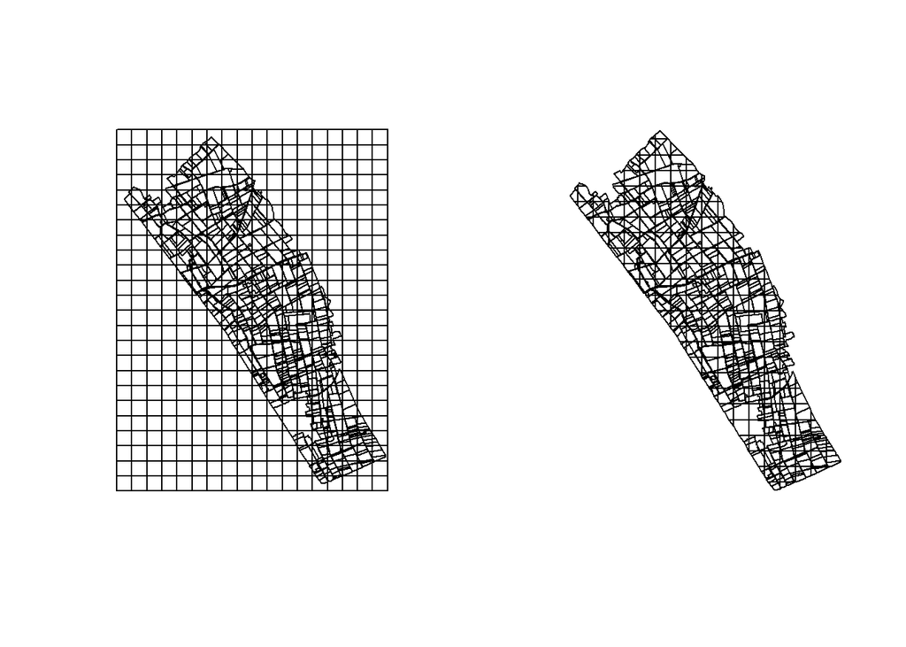

```r
# intersect
sel.grid <- raster::intersect(grid, land.cover)

# plot
par(mfrow=c(1,2))
plot(grid)
plot(land.cover, add=T)
plot(sel.grid)
```

Now we can calculate the area of each new shape.

```r
# area for each shape
sel.grid$area <- area(sel.grid)
```

And extract the size of each land cover inside a grid cell and reorganize it so that each grid cell is one row and each land cover is one column. If a land cover is presented in the grid, there will be a value in the column, if not, this means the LC is not present inside this grid cell.

```r
# for each grid/LC combination (id+LC) sum the areas
areas <- raster::aggregate(area~id+LUSE_21_Se, data=sel.grid, FUN=sum)
areas2 <- reshape2::dcast(areas, id ~ LUSE_21_Se)
knitr::kable(head(areas2))
```

| id | Bare_Soil | Cabbage | Carrot | Corn | Grass | Lattuce | Mustard_Radish | ND | Potato | Road | Settlement | Small_Crop | Sugar_Beet | Tree |
| --- | --- | --- | --- | --- | --- | --- | --- | --- | --- | --- | --- | --- | --- | --- |
| 14 | 21849.812 | NA | NA | NA | 1676.4484 | NA | NA | NA | NA | 680.3312 | NA | NA | NA | NA |
| 15 | 6258.466 | NA | NA | NA | 10550.0474 | NA | NA | NA | NA | 711.3464 | NA | NA | NA | NA |
| 31 | 2810.432 | NA | NA | NA | 373.8276 | NA | NA | NA | 7561.350 | NA | NA | NA | NA | NA |
| 32 | 59514.856 | NA | NA | NA | 11638.6821 | NA | NA | NA | 4005.565 | 5284.6234 | 5240.655 | NA | NA | NA |
| 33 | 67041.389 | NA | NA | NA | 21429.5131 | NA | NA | NA | NA | 1495.7510 | NA | NA | NA | NA |
| 34 | 36959.558 | NA | NA | NA | 2380.0276 | NA | 10825.4 | NA | NA | NA | NA | NA | 19524.69 | NA |

The rearanged areas calculation can be added to our master grid.

```r
grid <- sp::merge(grid, areas2, by="id")
```

### Step 3. SIF for each land cover inside each grid cell

```r
#change the name of the raster layer to reduce confusion later
names(sel.sif.2017) <- "SIF760.LC"
# extract sif for each Land Cover in each grid cell
sel.grid <- raster::extract(sel.sif.2017, sel.grid, fun=mean, na.rm=TRUE, sp=TRUE)

# same for SIF
# but change the names of LC before casting back into colums
sifs <- raster::aggregate(SIF760.LC~id+LUSE_21_Se, data=sel.grid, FUN=sum)
sifs$LUSE_21_Se <- as.factor(paste(as.character(sifs$LUSE_21_Se), "_SIF760", sep=""))
sifs2 <- reshape2::dcast(sifs, id ~ LUSE_21_Se)
knitr::kable(head(sifs2))
```

| id | Bare_Soil_SIF760 | Cabbage_SIF760 | Carrot_SIF760 | Corn_SIF760 | Grass_SIF760 | Lattuce_SIF760 | Mustard_Radish_SIF760 | ND_SIF760 | Potato_SIF760 | Road_SIF760 | Settlement_SIF760 | Small_Crop_SIF760 | Sugar_Beet_SIF760 | Tree_SIF760 |
| --- | --- | --- | --- | --- | --- | --- | --- | --- | --- | --- | --- | --- | --- | --- |
| 14 | 0.0779013 | NA | NA | NA | 0.1121376 | NA | NA | NA | NA | 0.0983398 | NA | NA | NA | NA |
| 15 | 0.2582532 | NA | NA | NA | 0.2184888 | NA | NA | NA | NA | 0.1880146 | NA | NA | NA | NA |
| 31 | 0.1593550 | NA | NA | NA | 0.2216562 | NA | NA | NA | 0.1479827 | NA | NA | NA | NA | NA |
| 32 | 0.6700056 | NA | NA | NA | 1.9282478 | NA | NA | NA | NA | 0.1254437 | 0.3844115 | NA | NA | NA |
| 33 | 0.6568708 | NA | NA | NA | 0.4283215 | NA | NA | NA | NA | 0.1911868 | NA | NA | NA | NA |
| 34 | 0.2895316 | NA | NA | NA | 0.4094327 | NA | 0.8394935 | NA | NA | NA | NA | NA | 0.5583393 | NA |

Finally, the values can be merged with our original grid using the unique grid cell id.

```r
grid <- sp::merge(grid, sifs2, by="id")
```

```r
names(grid)
```

```
##  [1] "id"                    "SIF760"
##  [3] "Bare_Soil"             "Cabbage"
##  [5] "Carrot"                "Corn"
##  [7] "Grass"                 "Lattuce"
##  [9] "Mustard_Radish"        "ND"
## [11] "Potato"                "Road"
## [13] "Settlement"            "Small_Crop"
## [15] "Sugar_Beet"            "Tree"
## [17] "Bare_Soil_SIF760"      "Cabbage_SIF760"
## [19] "Carrot_SIF760"         "Corn_SIF760"
## [21] "Grass_SIF760"          "Lattuce_SIF760"
## [23] "Mustard_Radish_SIF760" "ND_SIF760"
## [25] "Potato_SIF760"         "Road_SIF760"
## [27] "Settlement_SIF760"     "Small_Crop_SIF760"
## [29] "Sugar_Beet_SIF760"     "Tree_SIF760"
```

### Step 4. Dealing with partial grid cells

We have partial grid cells along the border of the study area. These will be excluded from the future analysis. To separate the full size grids from the ones which are cut on the border of the study we will use the fact that `intersect` keeps only overlapping portions of shapes. Thus border grids are smaller than the full size. By calculating the area of the grid cell we can identify what proportion of the grid has actual data. We will keep only those, which are at least 90% of the full pixel size by assigning a new column `keep` = 1.

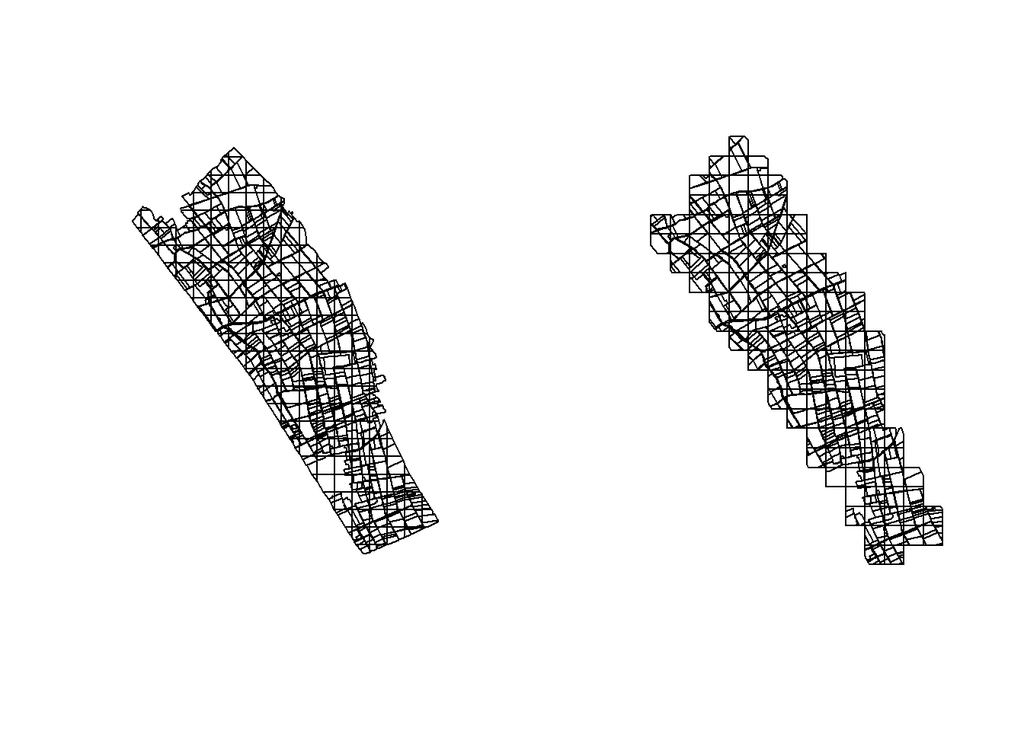

```r
# using the tidyverse synthax
grid.data <- as_tibble(sel.grid@data)

# melt back to 300 grid cell and calculate the area, and difference with
# full size grid cell
size <- grid.data %>% group_by(id) %>% summarise(area = sum(area)) %>% mutate(to.full = 300*300 - area)

# keep grid cells with at least 90% of full size
data.keep <- size %>% mutate(keep = ifelse(to.full < 9000, 1, 0)) %>% select(id, keep)

# append this as a new column to the grid
grid <- sp::merge(grid, data.keep, by="id")
sel.grid <- sp::merge(sel.grid, data.keep, by="id")

par(mfrow = c(1,2))
plot(sel.grid)
plot(sel.grid[sel.grid$keep == 1,])
```

## Post-processing

Using the keep column we can reduce the data to only those grid cells which are at least 90% in size and are falling above the study area.

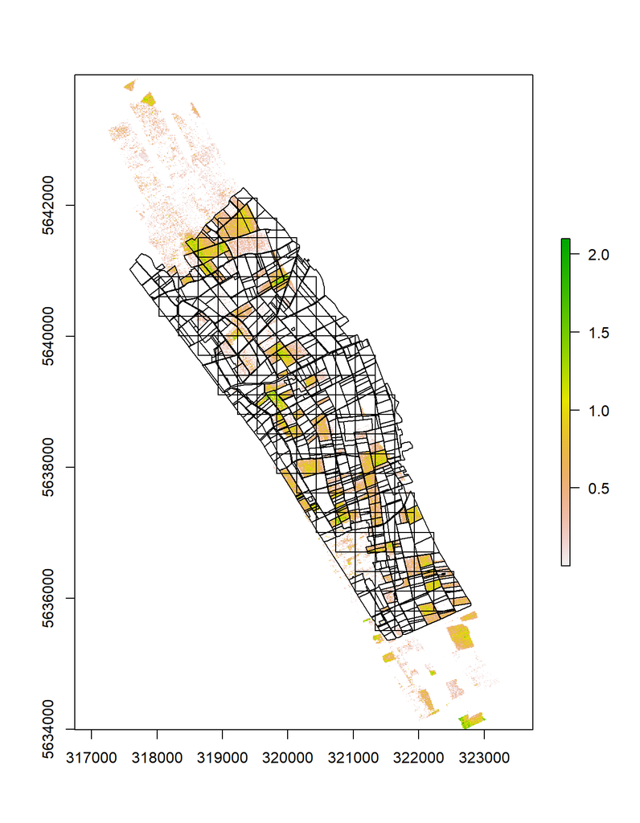

```r
plot(sel.sif.2017)
plot(land.cover, add=T)
plot(grid[!is.na(grid$keep) & grid$keep == 1,], add=T)
```